# homework_6

Stuart Miller

February 9, 2020

# Homework 6

## Problem 5.1

### Part A

Plot the data.

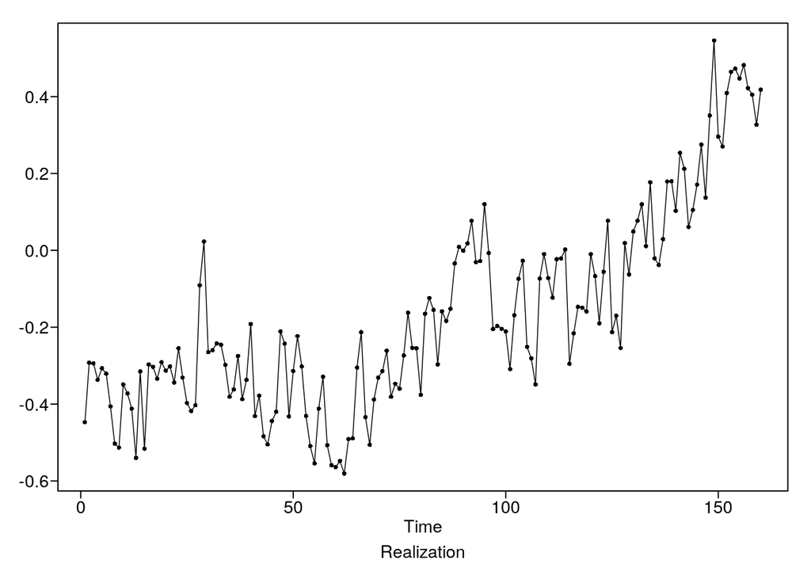

```r
plotts.wge(hadley)
```

### Part B

Fit a regression model as `hadley` ~ `time`.

```r
time <- seq_along(hadley)
model <- lm(hadley ~ time)
summary(model)
```

```
##
## Call:
## lm(formula = hadley ~ time)
##
## Residuals:
##      Min       1Q   Median       3Q      Max
## -0.33041 -0.11126 -0.00045  0.11489  0.42004
##
## Coefficients:
##               Estimate Std. Error t value Pr(>|t|)
## (Intercept) -0.5257370  0.0251087  -20.94   <2e-16 ***
## time         0.0044378  0.0002705   16.40   <2e-16 ***
## ---
## Signif. codes:  0 '***' 0.001 '**' 0.01 '*' 0.05 '.' 0.1 ' ' 1
##
## Residual standard error: 0.1581 on 158 degrees of freedom
## Multiple R-squared:   0.63,  Adjusted R-squared:  0.6277
## F-statistic: 269.1 on 1 and 158 DF,  p-value: < 2.2e-16
```

### Part C

Find and plot the residuals for the linear model.

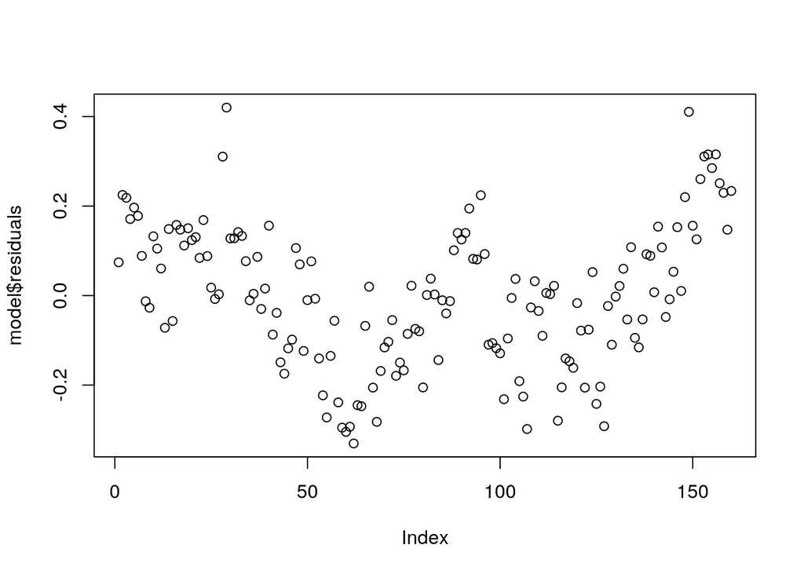

```r
plot(model$residuals)
```

### Part D

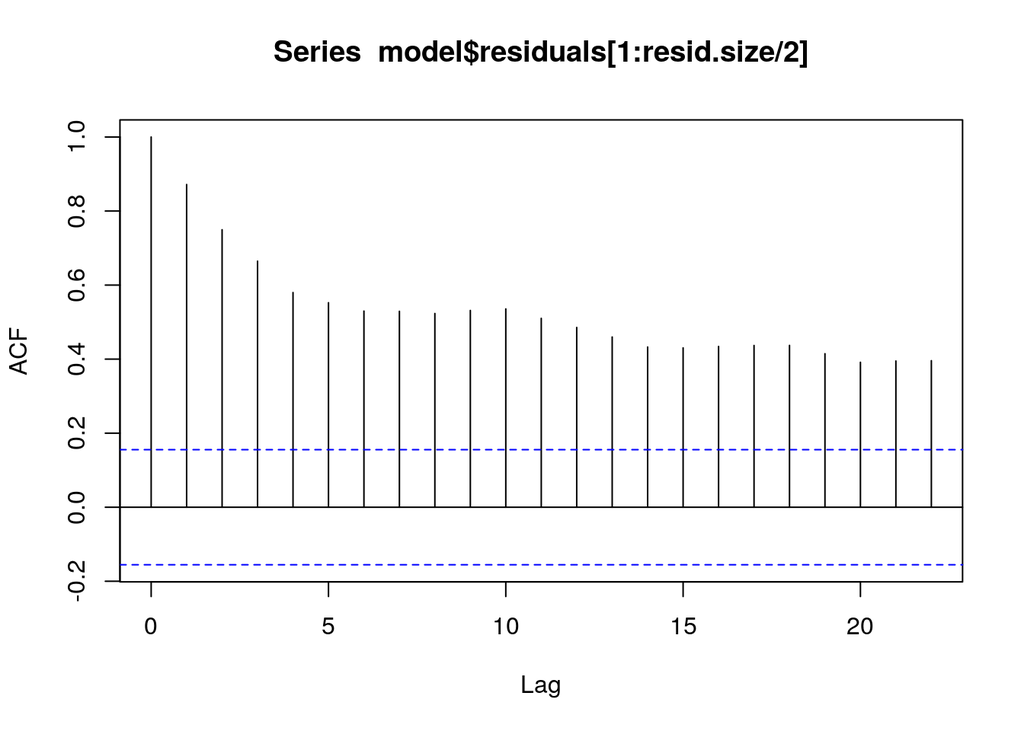

```r
resid.size <- length(model$residuals)
acf(model$residuals[1:resid.size/2])
```

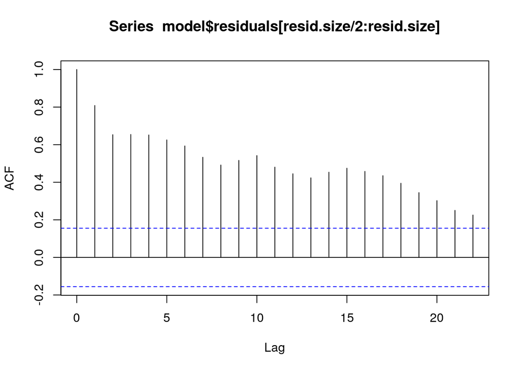

```r
acf(model$residuals[resid.size/2:resid.size])
```

### Part E

The autocorrelations of `hadley` are more slowly damping than the residuals. There is some suggestion of oscillatory behavior, but it is not strong.

The autocorrelations of the residuals of the linear model fall off much more rapidly. Additionally, there is stronger evidence of oscillator behavior.

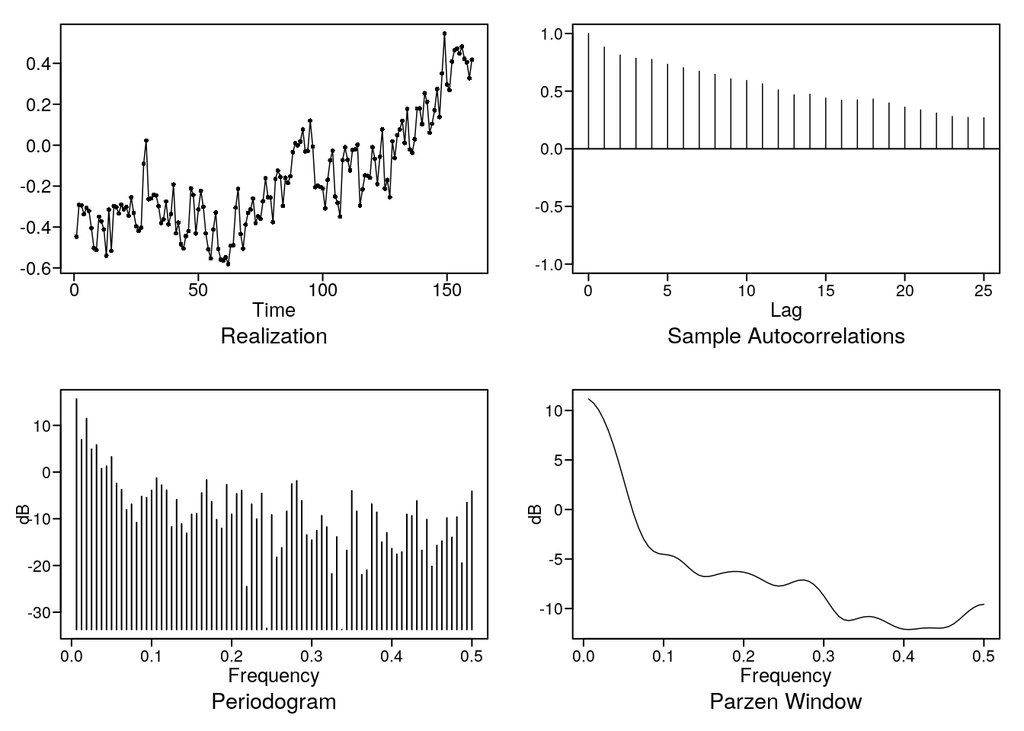

```
## $autplt
##  [1] 1.0000000 0.8820605 0.8128813 0.7852494 0.7752263 0.7331609 0.7031676
##  [8] 0.6727347 0.6463440 0.6061416 0.5928766 0.5630748 0.5107994 0.4681787
## [15] 0.4733601 0.4398667 0.4210580 0.4237071 0.4311625 0.3969888 0.3609513
## [22] 0.3374603 0.3103957 0.2803260 0.2720408 0.2699888
##
## $freq
##  [1] 0.00625 0.01250 0.01875 0.02500 0.03125 0.03750 0.04375 0.05000
##  [9] 0.05625 0.06250 0.06875 0.07500 0.08125 0.08750 0.09375 0.10000
## [17] 0.10625 0.11250 0.11875 0.12500 0.13125 0.13750 0.14375 0.15000
## [25] 0.15625 0.16250 0.16875 0.17500 0.18125 0.18750 0.19375 0.20000
## [33] 0.20625 0.21250 0.21875 0.22500 0.23125 0.23750 0.24375 0.25000
## [41] 0.25625 0.26250 0.26875 0.27500 0.28125 0.28750 0.29375 0.30000
## [49] 0.30625 0.31250 0.31875 0.32500 0.33125 0.33750 0.34375 0.35000
## [57] 0.35625 0.36250 0.36875 0.37500 0.38125 0.38750 0.39375 0.40000
```

[output cut: 38 more lines]

```r
plotts.sample.wge(hadley)
```

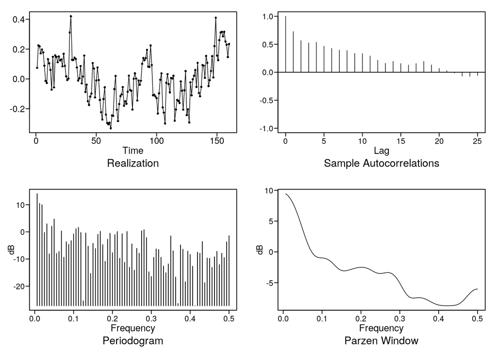

```
## $autplt
##  [1]  1.00000000  0.72756788  0.56564743  0.52397481  0.53612982
##  [6]  0.46526334  0.42603917  0.39656613  0.38700664  0.33716908
## [11]  0.33380081  0.29091460  0.21433524  0.15892538  0.19405827
## [16]  0.15591365  0.12919194  0.15564610  0.19445877  0.13105678
## [21]  0.06907000  0.02707135 -0.01325635 -0.06915329 -0.07226182
## [26] -0.05808824
##
## $freq
##  [1] 0.00625 0.01250 0.01875 0.02500 0.03125 0.03750 0.04375 0.05000
##  [9] 0.05625 0.06250 0.06875 0.07500 0.08125 0.08750 0.09375 0.10000
## [17] 0.10625 0.11250 0.11875 0.12500 0.13125 0.13750 0.14375 0.15000
## [25] 0.15625 0.16250 0.16875 0.17500 0.18125 0.18750 0.19375 0.20000
## [33] 0.20625 0.21250 0.21875 0.22500 0.23125 0.23750 0.24375 0.25000
## [41] 0.25625 0.26250 0.26875 0.27500 0.28125 0.28750 0.29375 0.30000
```

[output cut: 38 more lines]

```r
plotts.sample.wge(model$residuals)
```

## Problem 5.2

### Part A

Generate 3 realizations for the following model. Do any of the models appear to have a linear trend?

The first model appears to have a negative linear trend.

$$X_t - 0.66 X_{t-1} + 0.02 X_{t-2} - 0.10 X_{t-3} - 0.24 X_{t-4} = a_t$$

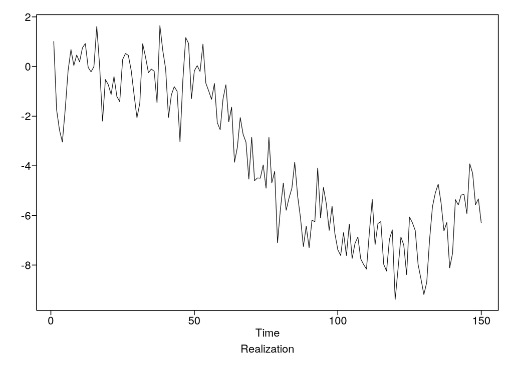

```r
phi <- c(0.66, -0.02, 0.1, 0.24)
x1 <- gen.arma.wge(n = 150, phi = phi, plot = T, sn = 1)
```

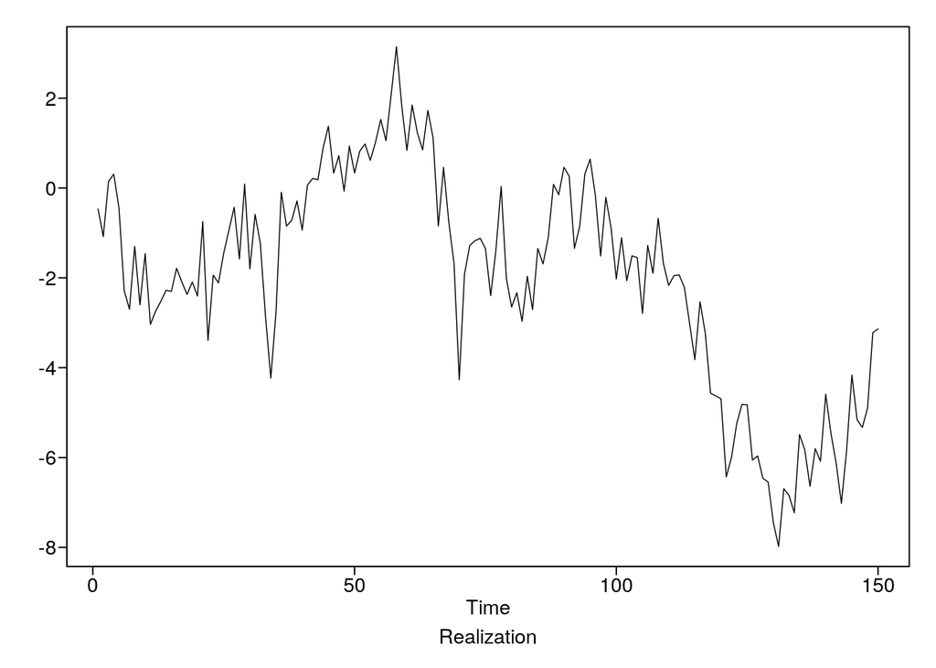

```r
x2 <- gen.arma.wge(n = 150, phi = phi, plot = T, sn = 42)
```

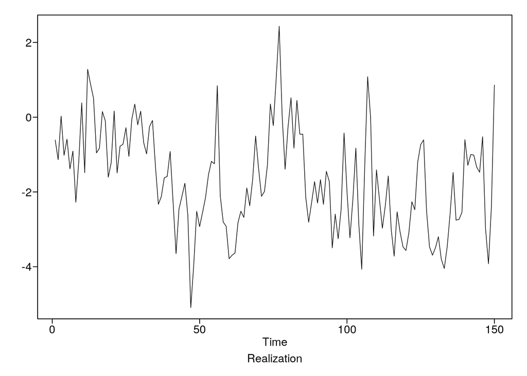

```r
x3 <- gen.arma.wge(n = 150, phi = phi, plot = T, sn = 35)
```

### Part B

Plot 4 realizations for the following model and compare to the hadley realization.

The forth realization looks similar to the hadley realization. The trends appear to be strong in the other realizations.

$$X_t = -0.526 + 0.0044t + Z_t$$

Where

$$(1 - 0.614 B + 0.044 B^2 - 0.077 B^3 - 0.0206 B^4) Z_t = 0$$

```r
phi <- c(0.614, -0.044, 0.077, 0.0206)
x1 <- gen.sigplusnoise.wge(n = 150, b0 = -0.526, b1 = 0.0044,
                           phi = phi, sn = 1, vara = 0.01)
```

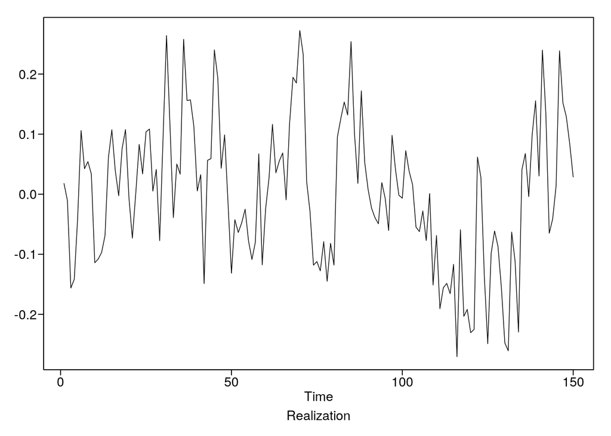

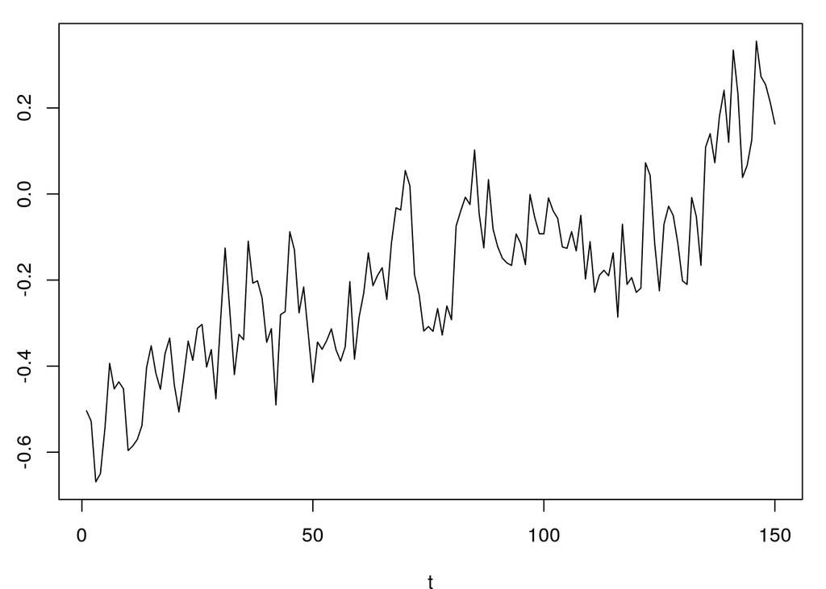

```r
x2 <- gen.sigplusnoise.wge(n = 150, b0 = -0.526, b1 = 0.0044,
                           phi = phi, sn = 42, vara = 0.01)
```

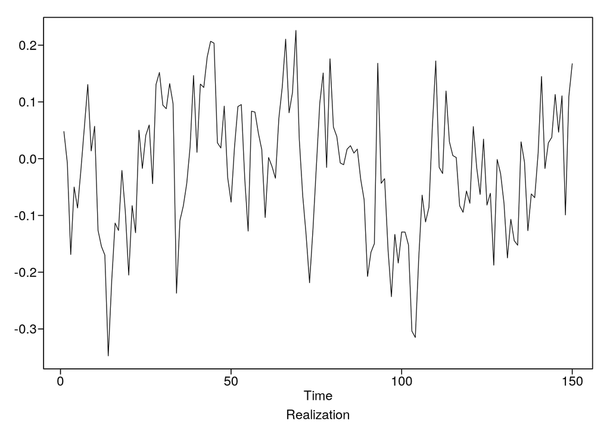

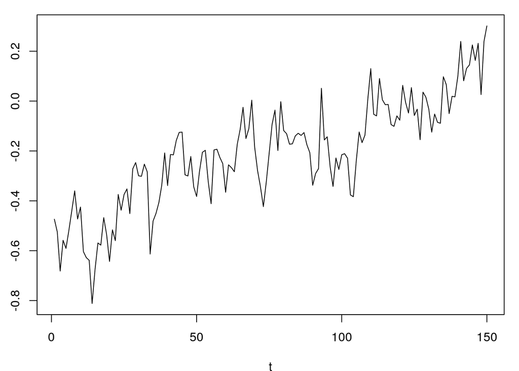

```r
x3 <- gen.sigplusnoise.wge(n = 150, b0 = -0.526, b1 = 0.0044,
                           phi = phi, sn = 37, vara = 0.01)
```

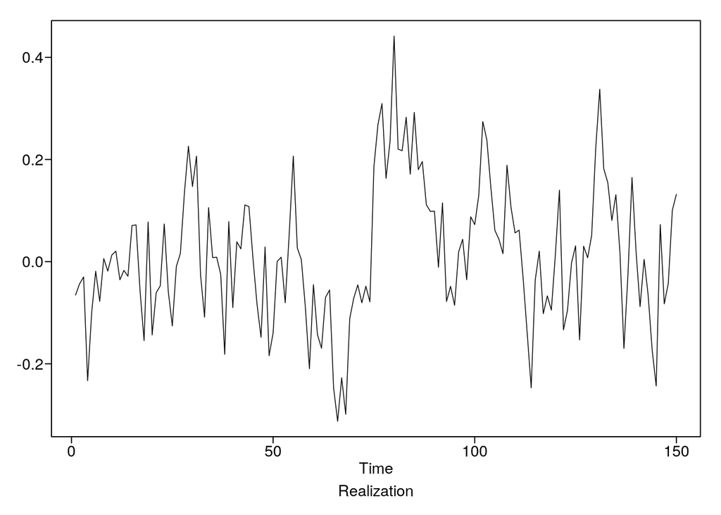

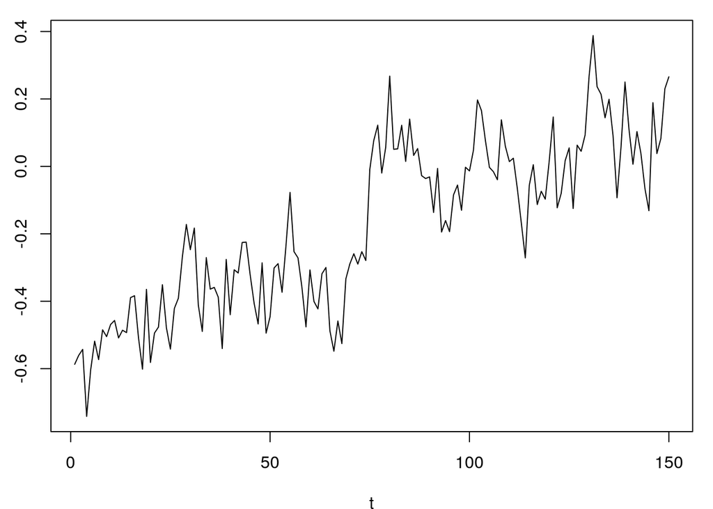

```r
x4 <- gen.sigplusnoise.wge(n = 150, b0 = -0.526, b1 = 0.0044,
                           phi = phi, sn = 35, vara = 0.01)
```

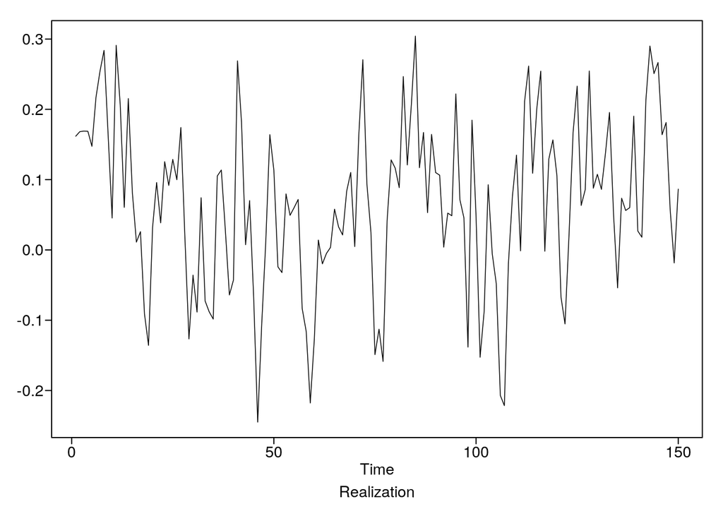

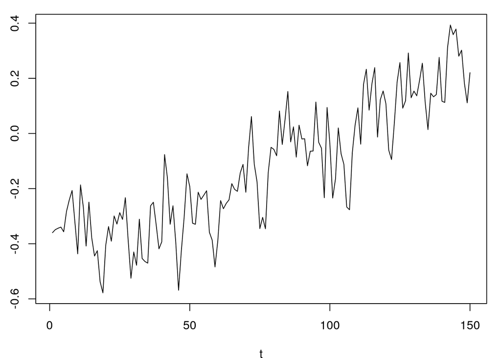

## Problem 5.3 (a, b, d)

For the following models generate a realziation and discuss the observable featrues. Additionalyl identify if the model is

- Stationary
- Non-stationary
- Seasonal (and non-stationary)

$$\left(1- 1.2B + 0.8 B^2 \right) (1-B) X_t = a_t$$

$$\left(1- 1.2B + 0.8 B^2 \right) (1-B)^2 X_t = a_t$$

$$\left(1- 1.2B + 0.8 B^2 \right) (1-B)^2 \left( 1 - B^4 \right)
\left(1 + B + B^2 \right) X_t = a_t$$

### Realizations

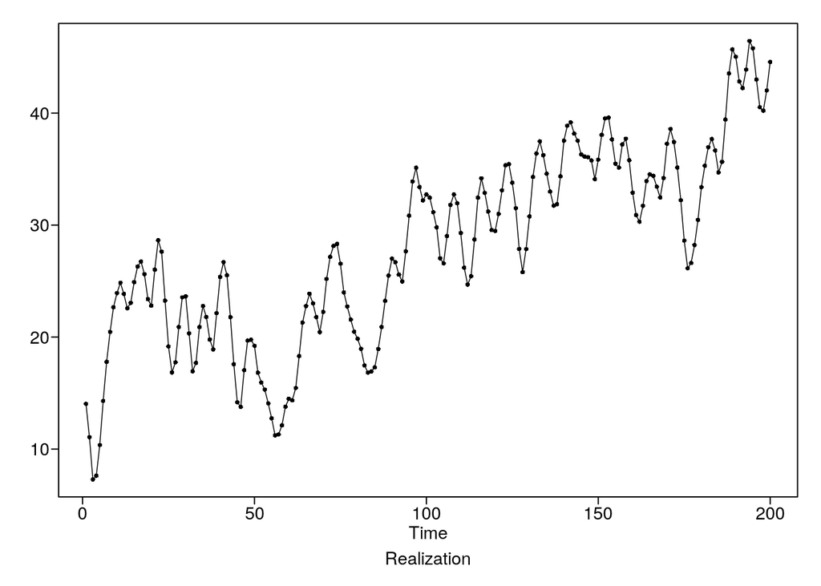

[output not shown]

```r
phi = c(1.2, -0.8)
gen.aruma.wge(n = 200, phi = phi, d = 1, sn = 3)
```

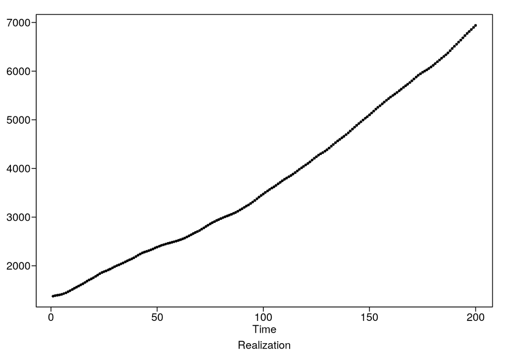

[output not shown]

```r
gen.aruma.wge(n = 200, phi = phi, d = 2, sn = 3)
```

```r
md <- gen.aruma.wge(n = 200, phi = phi, d = 1, s= 4, lambda = c(-1,-1), sn = 3)
```

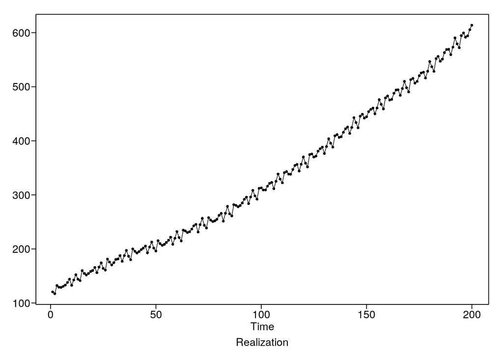

### Part A

Since this model has a root on the unit circle, it is non-stationary. The realization exhibits a psuedo-periodic behavior, which is consistent with the complex root in the AR porition of the model.

```r
factor.wge(phi = phi)
```

```
##
## Coefficients of Original polynomial:
## 1.2000 -0.8000
##
## Factor                 Roots                Abs Recip    System Freq
## 1-1.2000B+0.8000B^2    0.7500+-0.8292i      0.8944       0.1330
##
##
```

### Part B

The realization almost appears to be a linear trend. This model has two roots on the unit circle, which dominate the realiztion behavior.

### Part D

This model contains a quarterly seasonal factor, 2 roots on the unit circle, and addtional non-stationary factors. The model is dominated by the roots on the unit circle. The quarterly oscillatory behavior is also expressed.

```r
model.d <- mult.wge(phi,c(1,1),c(rep(0,3),1),c(-1,-1))
factor.wge(model.d$model.coef)
```

```
##
## Coefficients of Original polynomial:
## 1.2000 0.2000 0.8000 0.4000 -0.8000 0.6000 -0.8000 0.6000 -0.4000 -0.8000
##
## Factor                 Roots                Abs Recip    System Freq
## 1-1.6180B              0.6180               1.6180       0.0000
## 1+1.0000B             -1.0000               1.0000       0.5000
## 1+1.0000B+1.0000B^2   -0.5000+-0.8660i      1.0000       0.3333
## 1-1.0000B              1.0000               1.0000       0.0000
## 1+0.0000B+1.0000B^2    0.0000+-1.0000i      1.0000       0.2500
## 1-1.2000B+0.8000B^2    0.7500+-0.8292i      0.8944       0.1330
## 1+0.6180B             -1.6180               0.6180       0.5000
##
##
```

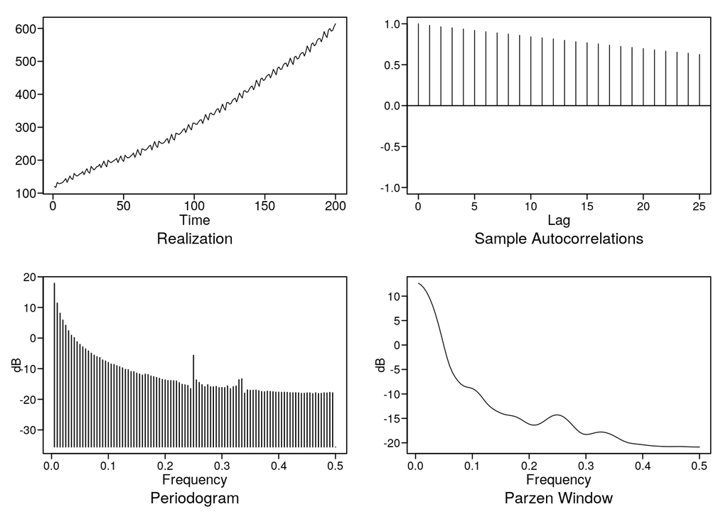

```
## $autplt
##  [1] 1.0000000 0.9813966 0.9639612 0.9512430 0.9368218 0.9192595 0.9029060
##  [8] 0.8889002 0.8753205 0.8588114 0.8413109 0.8282296 0.8156845 0.7980122
## [15] 0.7812838 0.7692959 0.7557436 0.7389902 0.7234077 0.7103006 0.6972902
## [22] 0.6816232 0.6652352 0.6529859 0.6410860 0.6243561
##
## $freq
##   [1] 0.005 0.010 0.015 0.020 0.025 0.030 0.035 0.040 0.045 0.050 0.055
##  [12] 0.060 0.065 0.070 0.075 0.080 0.085 0.090 0.095 0.100 0.105 0.110
##  [23] 0.115 0.120 0.125 0.130 0.135 0.140 0.145 0.150 0.155 0.160 0.165
##  [34] 0.170 0.175 0.180 0.185 0.190 0.195 0.200 0.205 0.210 0.215 0.220
##  [45] 0.225 0.230 0.235 0.240 0.245 0.250 0.255 0.260 0.265 0.270 0.275
##  [56] 0.280 0.285 0.290 0.295 0.300 0.305 0.310 0.315 0.320 0.325 0.330
##  [67] 0.335 0.340 0.345 0.350 0.355 0.360 0.365 0.370 0.375 0.380 0.385
##  [78] 0.390 0.395 0.400 0.405 0.410 0.415 0.420 0.425 0.430 0.435 0.440
```

[output cut: 46 more lines]

```r
plotts.sample.wge(md)
```

## Problem 5.5

### Part A

There are no canceling factors, the model is an ARUMA(2,4,2).

#### AR Factor Table

```r
factor.wge(c(3, -4.5, 5, -4, 2, -0.5))
```

```
##
## Coefficients of Original polynomial:
## 3.0000 -4.5000 5.0000 -4.0000 2.0000 -0.5000
##
## Factor                 Roots                Abs Recip    System Freq
## 1-1.0000B              1.0000               1.0000       0.0000
## 1+0.0000B+1.0000B^2    0.0000+-1.0000i      1.0000       0.2500
## 1-1.0000B              1.0000               1.0000       0.0000
## 1-1.0000B+0.5000B^2    1.0000+-1.0000i      0.7071       0.1250
##
##
```

#### MA Factor Table

```r
factor.wge(c(1.7,-0.8))
```

```
##
## Coefficients of Original polynomial:
## 1.7000 -0.8000
##
## Factor                 Roots                Abs Recip    System Freq
## 1-1.7000B+0.8000B^2    1.0625+-0.3480i      0.8944       0.0504
##
##
```

### Part B

The factored model is

$$(1-B) (1 + B + 0.8B^2) (1 + 0.5 B^2) (1 -0.5B) = 0$$

There are no canceling factors, the model is an ARUMA(5,1,0).

#### AR Factor Table

```r
factor.wge(c(0.5, -0.3, 0.95, -0.3, 0.35, -0.2))
```

```
##
## Coefficients of Original polynomial:
## 0.5000 -0.3000 0.9500 -0.3000 0.3500 -0.2000
##
## Factor                 Roots                Abs Recip    System Freq
## 1-1.0000B              1.0000               1.0000       0.0000
## 1+1.0000B+0.8000B^2   -0.6250+-0.9270i      0.8944       0.3444
## 1+0.0000B+0.5000B^2    0.0000+-1.4142i      0.7071       0.2500
## 1-0.5000B              2.0000               0.5000       0.0000
##
##
```

#### MA Factor Table

There are no MA factors

### Part C

The factored model is

$$(1+B) (1-1.5B+1B^2) (1-1B+0.8B^2) (1+0.5B^2) = (1+0.9B^2)$$

There are no canceling factors, the model is an ARUMA(4,3,2).

#### AR Factor Table

```r
factor.wge(c(1.5, -1.3, -0.35, 1, - 1.35 , 0.7, -0.4))
```

```
##
## Coefficients of Original polynomial:
## 1.5000 -1.3000 -0.3500 1.0000 -1.3500 0.7000 -0.4000
##
## Factor                 Roots                Abs Recip    System Freq
## 1+1.0000B             -1.0000               1.0000       0.5000
## 1-1.5000B+1.0000B^2    0.7500+-0.6614i      1.0000       0.1150
## 1-1.0000B+0.8000B^2    0.6250+-0.9270i      0.8944       0.1556
## 1+0.0000B+0.5000B^2    0.0000+-1.4142i      0.7071       0.2500
##
##
```

#### MA Factor Table

```r
factor.wge(c(0, -0.9))
```

```
##
## Coefficients of Original polynomial:
## 0.0000 -0.9000
##
## Factor                 Roots                Abs Recip    System Freq
## 1+0.0000B+0.9000B^2    0.0000+-1.0541i      0.9487       0.2500
##
##
```

### Part D

There are no canceling factors, the model is an ARUMA(1,5,2).

#### AR Factor Table

```r
factor.wge(c(0.5, 0.5, 0, 1, -0.5, -0.5))
```

```
##
## Coefficients of Original polynomial:
## 0.5000 0.5000 0.0000 1.0000 -0.5000 -0.5000
##
## Factor                 Roots                Abs Recip    System Freq
## 1-1.0000B              1.0000               1.0000       0.0000
## 1+1.0000B             -1.0000               1.0000       0.5000
## 1+0.0000B+1.0000B^2    0.0000+-1.0000i      1.0000       0.2500
## 1-1.0000B              1.0000               1.0000       0.0000
## 1+0.5000B             -2.0000               0.5000       0.5000
##
##
```

#### MA Factor Table

```r
factor.wge(c(0, 0.81))
```

```
##
## Coefficients of Original polynomial:
## 0.0000 0.8100
##
## Factor                 Roots                Abs Recip    System Freq
## 1+0.9000B             -1.1111               0.9000       0.5000
## 1-0.9000B              1.1111               0.9000       0.0000
##
##
```

## Problem 5.7

### Part A

The roots of unit are

- $\pm 1$
- $-0.5000 \pm 0.8660i$
- $0.5000 \pm 0.8660i$

```r
factor.wge(c(rep(0,5),1))
```

```
##
## Coefficients of Original polynomial:
## 0.0000 0.0000 0.0000 0.0000 0.0000 1.0000
##
## Factor                 Roots                Abs Recip    System Freq
## 1+1.0000B             -1.0000               1.0000       0.5000
## 1+1.0000B+1.0000B^2   -0.5000+-0.8660i      1.0000       0.3333
## 1-1.0000B+1.0000B^2    0.5000+-0.8660i      1.0000       0.1667
## 1-1.0000B              1.0000               1.0000       0.0000
##
##
```

### Part B and Part D

There is clear evidence of psuedo-periodic behavior. The autocorrelations do not match what would be expected from a theoretical prespective, but the strongest autocorrelations occur at intervals of 6, which is the expected behavior. The frequencies shown in the Parzen are similar to the ones in the factor table.

```r
x <- gen.aruma.wge(n = 120, s = 6, sn = 6)
```

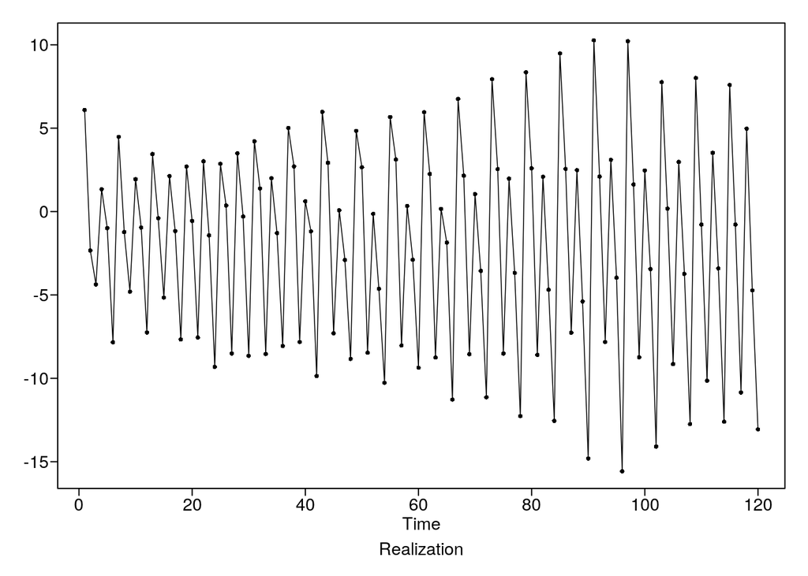

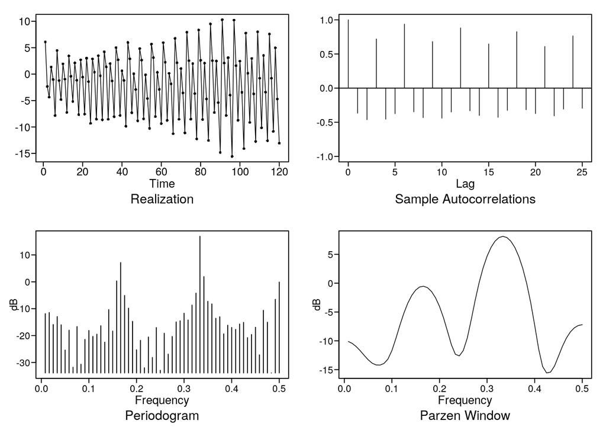

```
## $autplt
##  [1]  1.0000000 -0.3665373 -0.4619233  0.7198086 -0.4549125 -0.3742854
##  [7]  0.9380868 -0.3473056 -0.4319451  0.6813856 -0.4404600 -0.3494660
## [13]  0.8812489 -0.3319192 -0.4003563  0.6465991 -0.4275466 -0.3260751
## [19]  0.8268197 -0.3164253 -0.3723927  0.6098669 -0.4067575 -0.3075795
## [25]  0.7643696 -0.2941204
##
## $freq
##  [1] 0.008333333 0.016666667 0.025000000 0.033333333 0.041666667
##  [6] 0.050000000 0.058333333 0.066666667 0.075000000 0.083333333
## [11] 0.091666667 0.100000000 0.108333333 0.116666667 0.125000000
## [16] 0.133333333 0.141666667 0.150000000 0.158333333 0.166666667
## [21] 0.175000000 0.183333333 0.191666667 0.200000000 0.208333333
## [26] 0.216666667 0.225000000 0.233333333 0.241666667 0.250000000
## [31] 0.258333333 0.266666667 0.275000000 0.283333333 0.291666667
```

[output cut: 33 more lines]

```r
plotts.sample.wge(x)
```

### Part C

The true autocorrelations have a magnitude of 1 and occur periodically in intervals of 6. There are frequencies shown in true spectral density match the frequencies shown in the factor table.

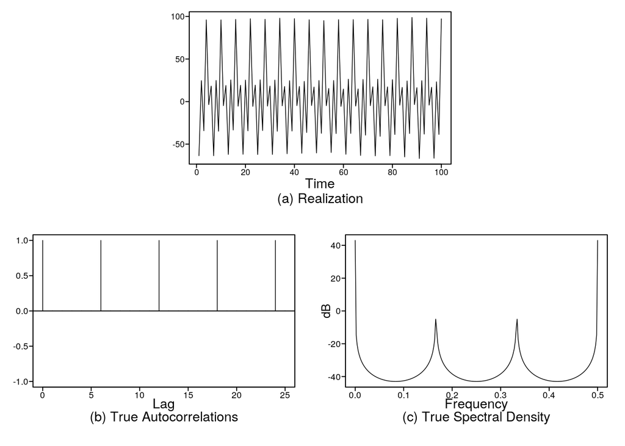

```
## $data
## Time Series:
## Start = 1
## End = 100
## Frequency = 1
##   [1] -63.552340  24.624715 -34.242819  95.985186  -3.606675  18.194451
##   [7] -63.584202  24.804856 -34.806960  95.981193  -4.776005  18.880572
##  [13] -62.059738  25.430495 -33.396210  96.506880  -5.413229  19.061715
##  [19] -61.886396  25.266447 -34.379451  97.329905  -5.650148  19.326455
##  [25] -62.184606  25.542429 -34.005823  96.683306  -5.317326  18.197395
##  [31] -62.097500  25.315987 -34.867387  97.965906  -4.956607  17.744106
##  [37] -61.276292  24.562411 -34.605590  97.460735  -4.735481  17.787505
##  [43] -60.760680  23.761306 -36.335380  96.167618  -4.606354  17.116505
##  [49] -60.373620  24.779989 -37.288875  95.176468  -4.863460  15.369036
##  [55] -59.808454  24.815154 -37.571118  96.257755  -5.654442  14.712635
```

[output cut: 57 more lines]

```r
plotts.true.wge(phi = c(rep(0,5),0.9999))
```